# Exploratory Data Analysis (EDA) & Visualization

## EDA: What, Why & Process

- **Exploratory Data Analysis (EDA)** is about understanding your data’s main characteristics, often visually, before formal modeling.
- **Why important?** Discover patterns, identify anomalies, test hypotheses, inform modeling, and communicate insights effectively.
- **Process:** It’s iterative:
  - **Ask Questions** -> **Wrangle** -> **Transform** -> **Visualize** -> **Model**
- Today: Questions & Visualization.

## Asking Questions: The Foundation of EDA

Before data analysis, formulate questions to guide your exploration. Good questions lead to meaningful insights.

Consider:

- **Distribution:** Typical values, spread, unusual values?
- **Relationship:** How do variables interact? Correlation?
- **Comparison:** How do groups compare on a metric?

Example:

- We download a dataset on age, income, education
- First Qs: What is the distribution of each variable? Is there a relationship between age, income, and education?

## Introduction to `ggplot2`

Most tools give you a **separate function for each chart type** — `hist()`, `barplot()`, `boxplot()`, `pie()`. Learn one, and it tells you nothing about the next.

`ggplot2` organizes things differently: you describe the **pieces** of a plot and add them together (the “grammar of graphics”). Every plot uses the same skeleton:

```
ggplot(data = <DATA>, aes(<MAPPINGS>)) +   # required: data + aesthetics
  <GEOM_FUNCTION>() +                      # required: what to draw
  <SCALES / FACETS / THEMES>()             # optional: refinement
```

- **Aesthetics** — which variable maps to x, y, color, size.
- **Geoms** — what to draw: `geom_point()`, `geom_bar()`, …
- **Everything else** — stats, facets, scales, themes — added only as needed.

Swap the geom and you get a different plot — the rest of the code stays put.

Cheat sheet: *Help > Cheat Sheets > Data Visualization with ggplot2*.

## Single variable plots

## Histograms: Visualizing Distributions

Display the distribution of a single continuous variable by showing the frequency of observations in defined bins.

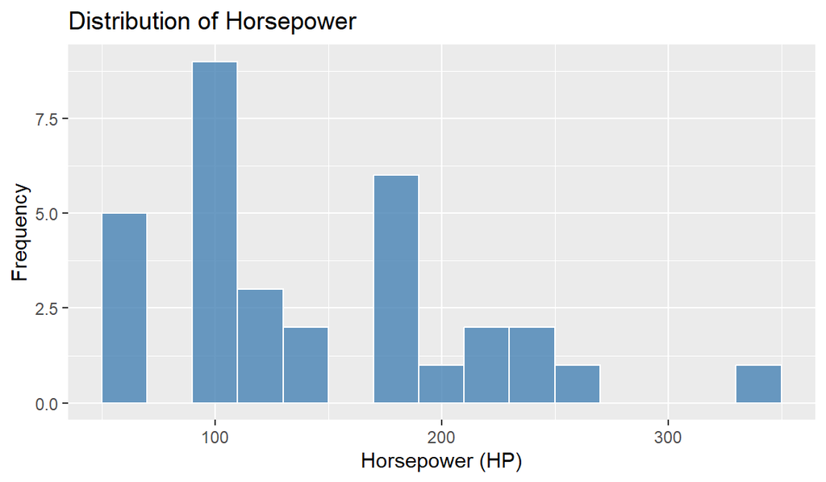

```r
# Histogram of horsepower
ggplot(data = mtcars, aes(x = hp)) +
  geom_histogram(binwidth = 20, fill = "steelblue", color = "white", alpha = 0.8) +
  labs(title = "Distribution of Horsepower", x = "Horsepower (HP)", y = "Frequency")
```

## Bar Charts: Visualizing Categories

Used to display counts or proportions of categorical variables, great for comparing values across different categories.

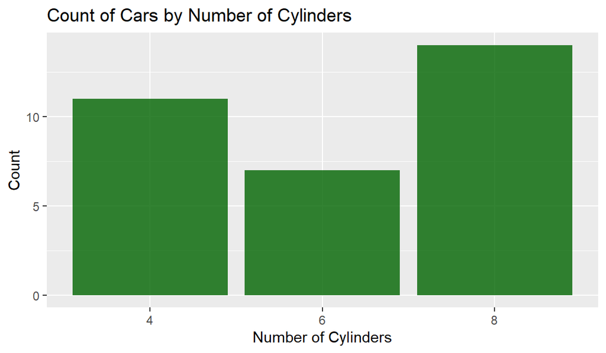

```r
# Bar chart of cylinder counts
ggplot(data = mtcars, aes(x = factor(cyl))) +
  geom_bar(fill = "darkgreen", alpha = 0.8) +
  labs(title = "Count of Cars by Number of Cylinders", x = "Number of Cylinders", y = "Count")
```

## Beyond single variables

## Scatter Plot

The most common way to start visualizing is by adding `geom_point()` to create a scatter plot, showing the relationship between two continuous variables.

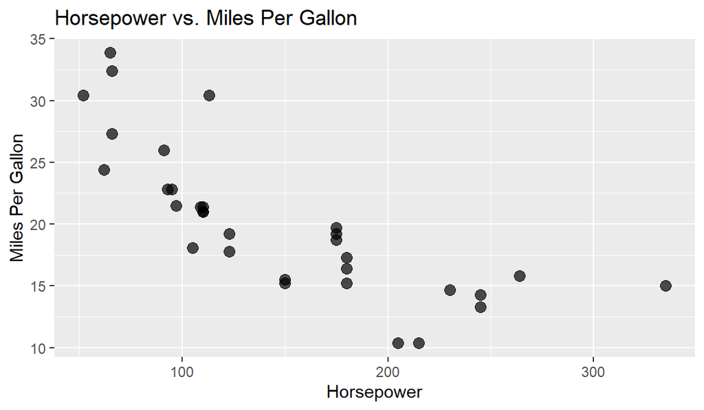

```r
# Scatter plot: MPG vs. HP
ggplot(data = mtcars, aes(x = hp, y = mpg)) + # Define data and basic aesthetics
  geom_point(size = 3, alpha = 0.7) + # Add points
  labs(title = "Horsepower vs. Miles Per Gallon", x = "Horsepower", y = "Miles Per Gallon")
```

## Aesthetic Mapping: Beyond X & Y

Besides `x` and `y`, `aes()` allows mapping data variables to other visual properties:

- `color`: Outline color for points/bars, line color.
- `fill`: Fill color for bars/polygons.
- `size`: Size of points or lines.
- `shape`: Shape of points.
- `alpha`: Transparency.
- `linetype`: Style of lines (solid, dashed, dotted).

## Aesthetic Mapping Example: Continuous Variables

Map a continuous variable to `color` or `size` to show its variation across data points.

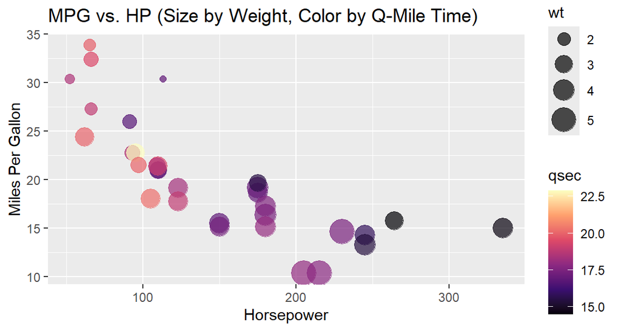

```r
ggplot(data = mtcars, aes(x = hp, y = mpg, size = wt, color = qsec)) + geom_point(alpha = 0.7) +
  scale_size_continuous(range = c(2, 8)) + # Control min/max size
  scale_color_viridis_c(option = "magma") + # Use a colorblind-friendly palette
  labs(title = "MPG vs. HP (Size by Weight, Color by Q-Mile Time)",x = "Horsepower", y = "Miles Per Gallon")
```

## Aesthetic Mapping Example: Categorical Variables

Map a categorical variable to `color` to distinguish groups.

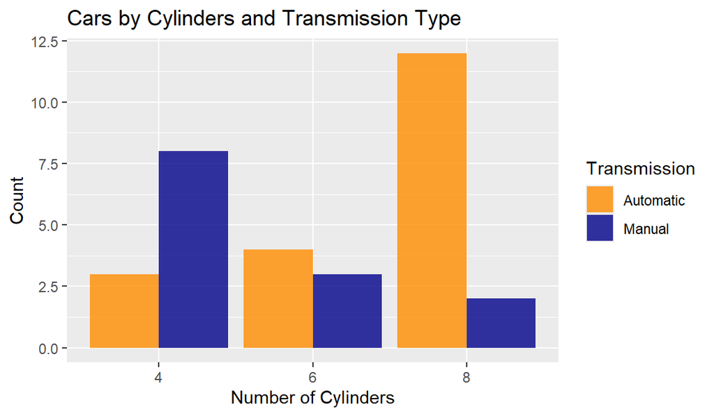

```r
ggplot(data = mtcars, aes(x = factor(cyl), fill = factor(am))) +
  geom_bar(position = "dodge", alpha = 0.8) + # 'dodge' separates bars by fill group
  scale_fill_manual(values = c("0" = "darkorange", "1" = "darkblue"), labels = c("Automatic", "Manual"), name = "Transmission") + labs(title = "Cars by Cylinders and Transmission Type", x = "Number of Cylinders", y = "Count")
```

## Stacked, Dodged, or Filled?

The `position` argument decides how bars sharing an x value are arranged. Same data, three answers:

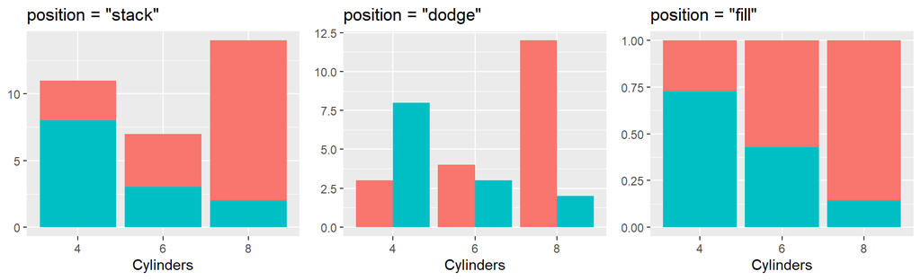

- `"stack"` (the default) — totals, split into parts.
- `"dodge"` — bars side by side, for comparing groups directly.
- `"fill"` — every bar to 100%, for comparing **shares**.

`"fill"` hides how big each bar is. Counts and shares answer different questions.

## Box Plots: Grouped Distributions

Summarize the distribution of a continuous variable for different categories, showing median, quartiles, and potential outliers.

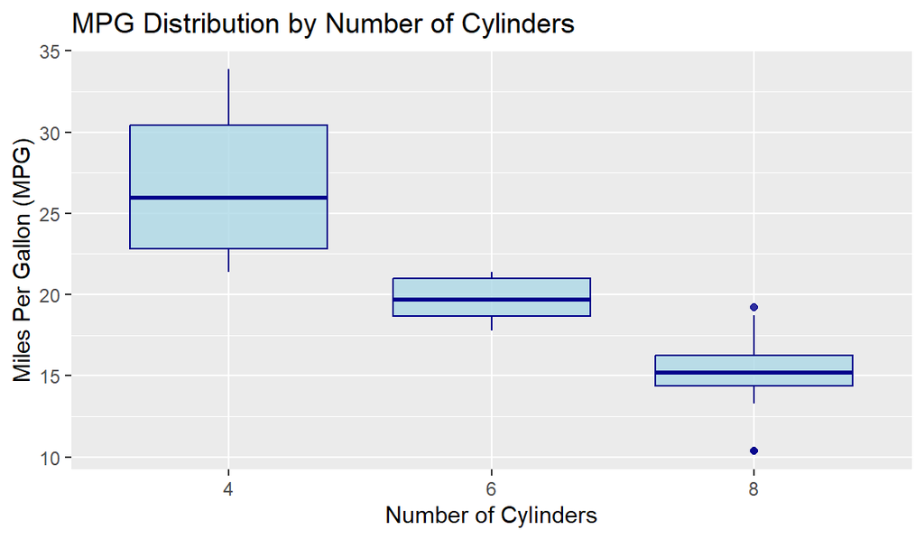

```r
# Box plot of MPG by number of cylinders
ggplot(data = mtcars, aes(x = factor(cyl), y = mpg)) +
  geom_boxplot(fill = "lightblue", color = "darkblue", alpha = 0.8) +
  labs(title = "MPG Distribution by Number of Cylinders", x = "Number of Cylinders", y = "Miles Per Gallon (MPG)")
```

## Line Plots: Showing Trends Over Time

Ideal for visualizing trends of one or more continuous variables over an ordered sequence, most commonly time.

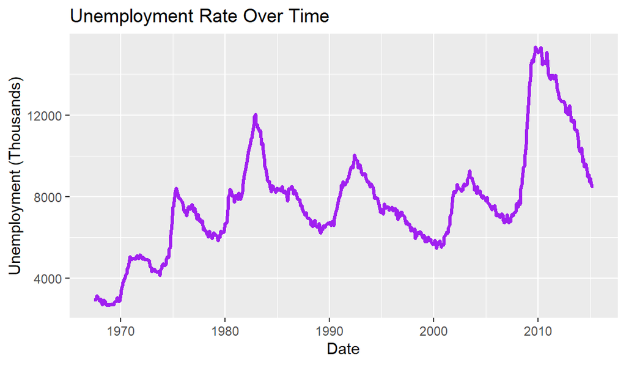

```r
# Example using a time series-like dataset (e.g., economics from ggplot2)
ggplot(data = economics, aes(x = date, y = unemploy)) +
  geom_line(color = "purple", linewidth = 1.2) +
  labs(title = "Unemployment Rate Over Time", x = "Date", y = "Unemployment (Thousands)")
```

## Area Plots: Visualizing Magnitude Over Time

Similar to line plots, but fill the area between the line and the x-axis. Useful for showing magnitude of change and total contribution over time.

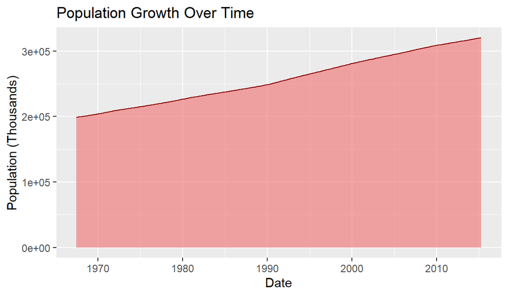

```r
# Example using economics data
ggplot(data = economics, aes(x = date, y = pop)) +
  geom_area(fill = "lightcoral", alpha = 0.7, color = "darkred") +
  labs(title = "Population Growth Over Time", x = "Date", y = "Population (Thousands)")
```

## Smooth Lines (`geom_smooth`)

`geom_smooth()` adds a smoothed mean to your plots, often used to visualize trends or relationships in scatter plots.

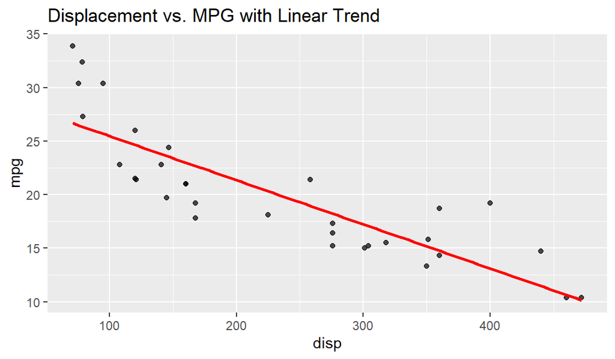

```r
# Scatter plot with a smoothed linear trend line
ggplot(data = mtcars, aes(x = disp, y = mpg)) +
  geom_point(alpha = 0.7) +
  geom_smooth(method = "lm", se = FALSE, color = "red") + labs(title = "Displacement vs. MPG with Linear Trend")
```

## Faceting: Subplots for Comparisons

Faceting allows you to create multiple subplots based on the levels of one or more categorical variables. Use `facet_wrap()` or `facet_grid()`.

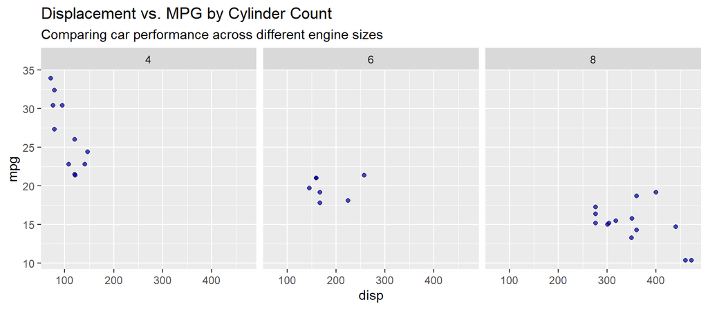

```r
ggplot(data = mtcars, aes(x = disp, y = mpg)) +
  geom_point(alpha = 0.7, color = "darkblue") +
  facet_wrap(~ cyl) + # Facet by 'cyl' variable
  labs(title = "Displacement vs. MPG by Cylinder Count",
       subtitle = "Comparing car performance across different engine sizes")
```

## Customizing Axes and Labels

You have fine-grained control over axis limits, breaks, and labels using `scale_x_continuous()`, `scale_y_continuous()`, and `labs()`.

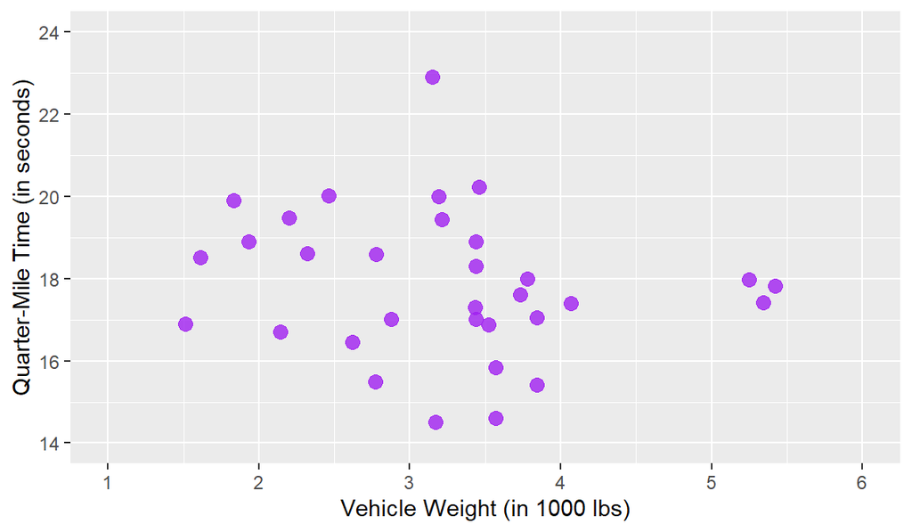

```r
ggplot(data = mtcars, aes(x = wt, y = qsec)) + geom_point(color = "purple", size = 3, alpha = 0.8) +
  labs(x = "Vehicle Weight (in 1000 lbs)", y = "Quarter-Mile Time (in seconds)") +
  scale_x_continuous(limits = c(1, 6), breaks = seq(1, 6, by = 1)) +
  scale_y_continuous(limits = c(14, 24), breaks = seq(14, 24, by = 2))
```

## Adding Titles and Subtitles

Clear titles and subtitles are essential for making your plots informative and easy to understand. Use `labs()` to add these elements.

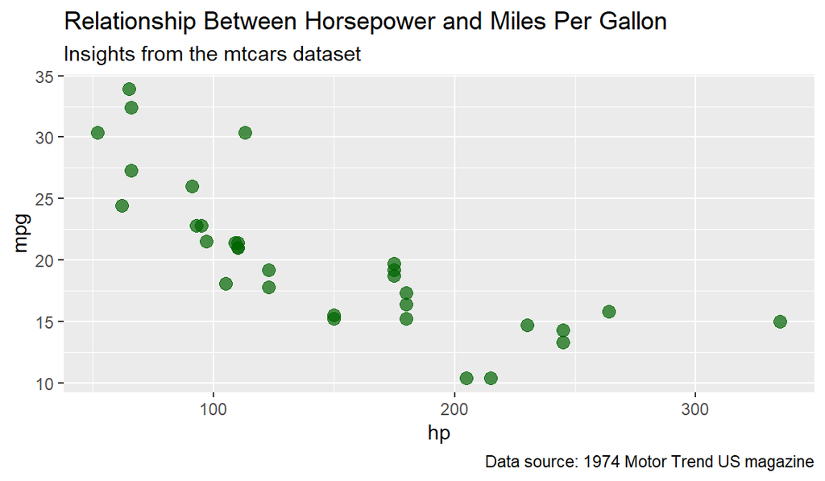

```r
ggplot(data = mtcars, aes(x = hp, y = mpg)) +
  geom_point(color = "darkgreen", size = 3, alpha = 0.7) +
  labs(title = "Relationship Between Horsepower and Miles Per Gallon", subtitle = "Insights from the mtcars dataset",caption = "Data source: 1974 Motor Trend US magazine")
```

## Customizing Colors and Fills

`ggplot2` provides powerful `scale_color_` and `scale_fill_` functions to control the colors used in your plots.

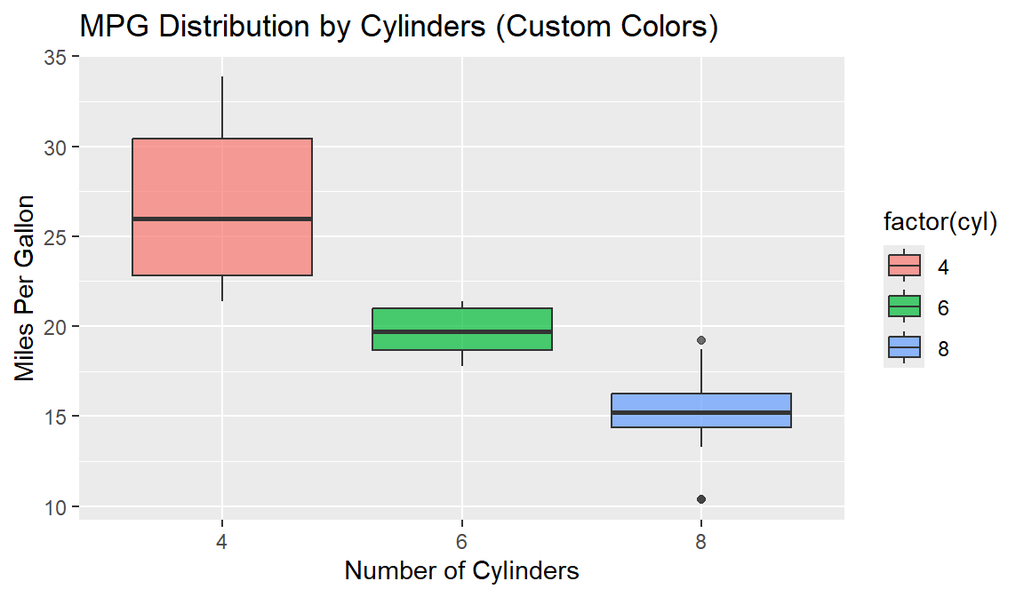

```r
# Example using manual colors for a categorical variable
ggplot(data = mtcars, aes(x = factor(cyl), y = mpg, fill = factor(cyl))) +
  geom_boxplot(alpha = 0.7) +
  scale_fill_discrete() +
  labs(title = "MPG Distribution by Cylinders (Custom Colors)", x = "Number of Cylinders", y = "Miles Per Gallon")
```

## Introduction to Geographic Mapping in R (`sf`)

- Mapping visualizes data in a spatial context, revealing geographic patterns.
- The `sf` (Simple Features) package is the modern standard for handling spatial data in R, integrating seamlessly with `ggplot2`.

**Spatial Data Types:**

- **Points:** Single locations (e.g., cities).
- **Lines:** Roads, rivers, boundaries.
- **Polygons:** Countries, states, lakes.

## Loading Spatial Data & Basic Static Map

We’ll use `rnaturalearth` for built-in world map data and then create a basic static map.

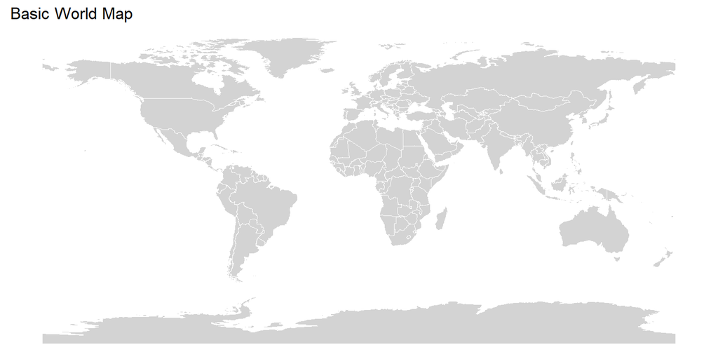

```r
# Load world map data
world <- ne_countries(scale = "medium", returnclass = "sf")
# Basic world map
ggplot(data = world) +
  geom_sf(fill = "lightgray", color = "white", size = 0.2) + theme_void() + labs(title = "Basic World Map")
```

## Thematic Mapping: Choropleth Maps

Choropleth maps color geographic areas based on a variable’s value, showing spatial distribution. We map a data variable to the `fill` aesthetic of `geom_sf()`.

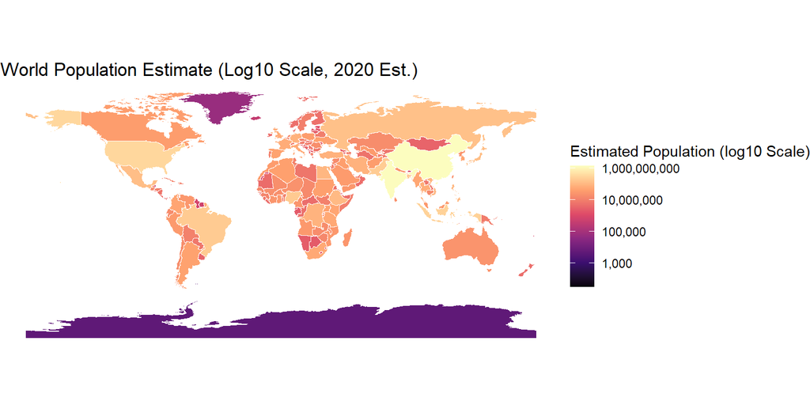

```r
ggplot(data = world) +
  geom_sf(aes(fill = pop_est), color = "white", size = 0.2) +
  scale_fill_viridis_c(option = "magma", name = "Estimated Population (log10 Scale)",
                       labels = scales::comma, trans = "log10") + # Apply log10 transformation
  theme_void() + labs(title = "World Population Estimate (Log10 Scale, 2020 Est.)")
```

## Adding Points and Lines to Maps

Overlay additional spatial data (points, lines, or other polygons) on your base map by adding more `geom_sf()` layers.

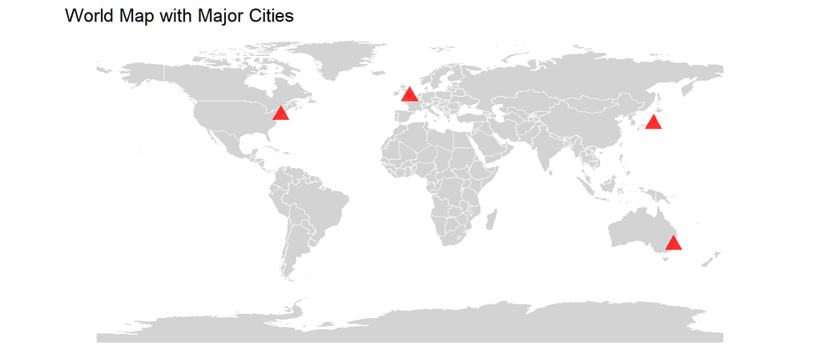

```r
# Plot world map with cities
ggplot(data = world) +
  geom_sf(fill = "lightgray", color = "white", size = 0.2) +
  geom_sf(data = cities, color = "red", size = 4, shape = 17, alpha = 0.8) + # Add city points
  theme_void() + labs(title = "World Map with Major Cities")
```

## Common Pitfalls in Visualization

- **Misleading Scales:** Truncating axes or non-zero baselines distort perception.
- **Overplotting:** Too many points obscure patterns.
- **Poor Color Choices:** Inaccessible palettes or too many colors.
- **Lack of Labels/Titles:** Plots without clear context are hard to interpret.
- **Using 3D when 2D Suffices:** Adds complexity without clarity.
- **Ignoring Data Types:** Inappropriate plots for categorical vs. continuous data.

## Pitfall in Action: Misleading Scales

Same data, same period. Only the y-axis differs.

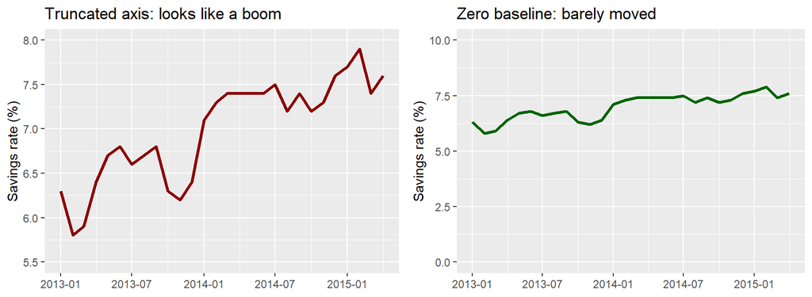

The savings rate rose about 20% over this window — the left panel sells that as a dramatic surge, the right as almost nothing. **Neither axis is “wrong”; the choice is an argument.**

## Summary

Today we covered:

- **EDA:** ask the question first, then pick the plot.
- **Grammar of graphics:** data + aesthetics + geoms, composed in layers.
- **One variable:** histograms and bar charts.
- **Two or more:** scatter, box, line, area — plus color, size, and faceting.
- **Maps:** `sf` and `geom_sf()` for choropleths and points.
- **Pitfalls:** the axis is an argument.

In RStudio: *Help > Cheat Sheets > Data Visualization with ggplot2*

## For rest of class

- Work on the `day5_activity`
- Ask me questions if you run into issues